# Taller 7

Métodos Computacionales para Políticas Públicas - URosario

**Entrega: viernes 5-oct-2018 11:59 PM**

**[Juan Camilo Perdomo]**  
[juan.perdomo@urosario.edu.co]

## Instrucciones:

- Guarde una copia de este *Jupyter Notebook* en su computador, idealmente en una carpeta destinada al material del curso.
- Modifique el nombre del archivo del *notebook*, agregando al final un guión inferior y su nombre y apellido, separados estos últimos por otro guión inferior. Por ejemplo, mi *notebook* se llamaría: mcpp_taller7_santiago_matallana
- Marque el *notebook* con su nombre y e-mail en el bloque verde arriba. Reemplace el texto "[Su nombre acá]" con su nombre y apellido. Similar para su e-mail.
- Desarrolle la totalidad del taller sobre este *notebook*, insertando las celdas que sea necesario debajo de cada pregunta. Haga buen uso de las celdas para código y de las celdas tipo *markdown* según el caso.
- Recuerde salvar periódicamente sus avances.
- Cuando termine el taller:
  1. Descárguelo en PDF. Si tiene algún problema con la conversión, descárguelo en HTML.
  2. Suba todos los archivos a su repositorio en GitHub, en una carpeta destinada exclusivamente para este taller, antes de la fecha y hora límites.

(Todos los ejercicios tienen el mismo valor.)

Este taller tiene dos partes. Una obligatoria, relativamente fácil, y otra voluntaria y más retadora. Los invito a intentar desarrollar el taller en su totalidad.

En este taller exploraremos los datos de crimen de Chicago.

Descargue los datos de crimen del Chicago Data Portal solo para el año 2015 (https://data.cityofchicago.org/Public-Safety/Crimes-2001-to-present/ijzp-q8t2/data).

```python
import pandas as pd
import numpy as np
import matplotlib.pyplot as plt
%matplotlib inline
plt.rcParams["figure.figsize"] = [18.0, 10.0]
plt.style.use('ggplot')
```

```python
crimes = pd.read_csv('Crimes_-_2001_to_present.csv')
```

```python
crimes
```

|  | ID | Case Number | Date | Block | IUCR | Primary Type | Description | Location Description | Arrest | Domestic | ... | Ward | Community Area | FBI Code | X Coordinate | Y Coordinate | Year | Updated On | Latitude | Longitude | Location |
| --- | --- | --- | --- | --- | --- | --- | --- | --- | --- | --- | --- | --- | --- | --- | --- | --- | --- | --- | --- | --- | --- |
| 0 | 10201852 | HY389096 | 01/01/2015 12:00:00 AM | 008XX N MAPLEWOOD AVE | 2825 | OTHER OFFENSE | HARASSMENT BY TELEPHONE | APARTMENT | False | True | ... | 1 | 24 | 26 | 1159250.0 | 1905420.0 | 2015 | 08/20/2015 04:17:37 PM | 41.896198 | -87.690553 | (41.896197984, -87.690552821) |
| 1 | 10060114 | HY239140 | 01/01/2015 12:00:00 AM | 069XX S CORNELL AVE | 1751 | OFFENSE INVOLVING CHILDREN | CRIM SEX ABUSE BY FAM MEMBER | RESIDENCE | False | False | ... | 5 | 43 | 20 | 1188551.0 | 1859284.0 | 2015 | 08/17/2015 03:03:40 PM | 41.768946 | -87.584415 | (41.768945532, -87.584414851) |
| 2 | 10210454 | HY397301 | 01/01/2015 12:00:00 AM | 049XX W WABANSIA AVE | 0266 | CRIM SEXUAL ASSAULT | PREDATORY | RESIDENCE | False | True | ... | 37 | 25 | 02 | NaN | NaN | 2015 | 08/31/2015 03:43:09 PM | NaN | NaN | NaN |
| 3 | 10025440 | HY214766 | 01/01/2015 12:00:00 AM | 004XX E 80TH ST | 1154 | DECEPTIVE PRACTICE | FINANCIAL IDENTITY THEFT $300 AND UNDER | RESIDENCE | False | True | ... | 6 | 44 | 11 | 1180776.0 | 1852066.0 | 2015 | 08/17/2015 03:03:40 PM | 41.749321 | -87.613135 | (41.749320815, -87.613135423) |
| 4 | 10225520 | HY412735 | 01/01/2015 12:00:00 AM | 075XX S BLACKSTONE AVE | 1153 | DECEPTIVE PRACTICE | FINANCIAL IDENTITY THEFT OVER $ 300 | RESIDENCE | False | False | ... | 5 | 43 | 11 | NaN | NaN | 2015 | 09/10/2015 11:43:14 AM | NaN | NaN | NaN |
| 5 | 10298217 | HY486593 | 01/01/2015 12:00:00 AM | 013XX S THROOP ST | 1752 | OFFENSE INVOLVING CHILDREN | AGG CRIM SEX ABUSE FAM MEMBER | STREET | False | False | ... | 2 | 28 | 20 | NaN | NaN | 2015 | 11/03/2015 03:59:23 PM | NaN | NaN | NaN |
| 6 | 10251294 | HY438848 | 01/01/2015 12:00:00 AM | 030XX W VAN BUREN ST | 1562 | SEX OFFENSE | AGG CRIMINAL SEXUAL ABUSE | RESIDENCE | False | False | ... | 28 | 27 | 17 | NaN | NaN | 2015 | 09/30/2015 03:35:37 PM | NaN | NaN | NaN |
| 7 | 10348954 | HY539840 | 01/01/2015 12:00:00 AM | 026XX W AGATITE AVE | 1752 | OFFENSE INVOLVING CHILDREN | AGG CRIM SEX ABUSE FAM MEMBER | RESIDENCE | False | True | ... | 47 | 4 | 20 | NaN | NaN | 2015 | 12/17/2015 03:55:47 PM | NaN | NaN | NaN |
| 8 | 10249793 | HY437344 | 01/01/2015 12:00:00 AM | 078XX S MERRILL AVE | 0266 | CRIM SEXUAL ASSAULT | PREDATORY | RESIDENCE | False | True | ... | 8 | 43 | 02 | NaN | NaN | 2015 | 09/30/2015 03:35:37 PM | NaN | NaN | NaN |
| 9 | 10055136 | HY244136 | 01/01/2015 12:00:00 AM | 105XX S LAFAYETTE AVE | 1544 | SEX OFFENSE | SEXUAL EXPLOITATION OF A CHILD | RESIDENCE | False | False | ... | 34 | 49 | 17 | 1177794.0 | 1834956.0 | 2015 | 08/17/2015 03:03:40 PM | 41.702437 | -87.624579 | (41.702436739, -87.624578804) |
| 10 | 10225760 | HY412902 | 01/01/2015 12:00:00 AM | 050XX N MARINE DR | 0810 | THEFT | OVER $500 | APARTMENT | False | False | ... | 48 | 3 | 06 | NaN | NaN | 2015 | 09/10/2015 11:43:14 AM | NaN | NaN | NaN |
| 11 | 9963311 | HY152624 | 01/01/2015 12:00:00 AM | 054XX S INDIANA AVE | 1710 | OFFENSE INVOLVING CHILDREN | ENDANGERING LIFE/HEALTH CHILD | APARTMENT | False | False | ... | 3 | 40 | 26 | 1178526.0 | 1868931.0 | 2015 | 08/17/2015 03:03:40 PM | 41.795652 | -87.620868 | (41.79565153, -87.620868294) |
| 12 | 9911347 | HY100371 | 01/01/2015 12:00:00 AM | 032XX S ABERDEEN ST | 2825 | OTHER OFFENSE | HARASSMENT BY TELEPHONE | RESIDENCE | False | False | ... | 11 | 60 | 26 | 1169514.0 | 1883135.0 | 2015 | 08/17/2015 03:03:40 PM | 41.834829 | -87.653503 | (41.834828981, -87.653503477) |
| 13 | 10357502 | HY548591 | 01/01/2015 12:00:00 AM | 059XX W GUNNISON ST | 1544 | SEX OFFENSE | SEXUAL EXPLOITATION OF A CHILD | RESIDENCE | False | True | ... | 45 | 15 | 17 | NaN | NaN | 2015 | 12/30/2015 04:03:21 PM | NaN | NaN | NaN |
| 14 | 9919306 | HY108256 | 01/01/2015 12:00:00 AM | 032XX S WALLACE ST | 1150 | DECEPTIVE PRACTICE | CREDIT CARD FRAUD | APARTMENT | False | False | ... | 11 | 60 | 11 | 1172823.0 | 1883486.0 | 2015 | 08/17/2015 03:03:40 PM | 41.835720 | -87.641352 | (41.83571965, -87.641351509) |
| 15 | 10069755 | HY258329 | 01/01/2015 12:00:00 AM | 015XX N KEYSTONE AVE | 1752 | OFFENSE INVOLVING CHILDREN | AGG CRIM SEX ABUSE FAM MEMBER | RESIDENCE | False | True | ... | 30 | 23 | 20 | 1149102.0 | 1909874.0 | 2015 | 08/17/2015 03:03:40 PM | 41.908623 | -87.727709 | (41.908622792, -87.727709185) |
| 16 | 10210466 | HY397304 | 01/01/2015 12:00:00 AM | 010XX W BELMONT AVE | 1751 | OFFENSE INVOLVING CHILDREN | CRIM SEX ABUSE BY FAM MEMBER | RESIDENCE | False | True | ... | 44 | 6 | 20 | NaN | NaN | 2015 | 08/31/2015 03:43:09 PM | NaN | NaN | NaN |
| 17 | 10274300 | HY462262 | 01/01/2015 12:00:00 AM | 018XX N CALIFORNIA AVE | 1153 | DECEPTIVE PRACTICE | FINANCIAL IDENTITY THEFT OVER $ 300 | APARTMENT | False | False | ... | 1 | 22 | 11 | NaN | NaN | 2015 | 10/15/2015 03:57:16 PM | NaN | NaN | NaN |
| 18 | 10392715 | HZ129023 | 01/01/2015 12:00:00 AM | 074XX S YATES BLVD | 1544 | SEX OFFENSE | SEXUAL EXPLOITATION OF A CHILD | RESIDENCE | False | False | ... | 7 | 43 | 17 | NaN | NaN | 2015 | 01/27/2016 04:00:46 PM | NaN | NaN | NaN |
| 19 | 10136559 | HY325033 | 01/01/2015 12:00:00 AM | 043XX S WESTERN AVE | 1752 | OFFENSE INVOLVING CHILDREN | AGG CRIM SEX ABUSE FAM MEMBER | APARTMENT | False | True | ... | 12 | 58 | 20 | 1161089.0 | 1875932.0 | 2015 | 08/17/2015 03:03:40 PM | 41.815242 | -87.684617 | (41.815241927, -87.684616785) |
| 20 | 9927080 | HY115682 | 01/01/2015 12:00:00 AM | 030XX W ARTHINGTON ST | 1310 | CRIMINAL DAMAGE | TO PROPERTY | APARTMENT | False | False | ... | 28 | 27 | 14 | 1156289.0 | 1895884.0 | 2015 | 08/17/2015 03:03:40 PM | 41.870091 | -87.701686 | (41.870090632, -87.70168581) |
| 21 | 10024172 | HY212630 | 01/01/2015 12:00:00 AM | 078XX S MAY ST | 1753 | OFFENSE INVOLVING CHILDREN | SEX ASSLT OF CHILD BY FAM MBR | RESIDENCE | False | False | ... | 17 | 71 | 02 | 1170011.0 | 1852871.0 | 2015 | 08/17/2015 03:03:40 PM | 41.751770 | -87.652559 | (41.751770335, -87.65255922) |
| 22 | 10262792 | HY450465 | 01/01/2015 12:00:00 AM | 077XX S DR MARTIN LUTHER KING JR DR | 1154 | DECEPTIVE PRACTICE | FINANCIAL IDENTITY THEFT $300 AND UNDER | RESIDENCE | False | False | ... | 6 | 69 | 11 | NaN | NaN | 2015 | 10/09/2015 03:58:54 PM | NaN | NaN | NaN |
| 23 | 10045724 | HY234319 | 01/01/2015 12:00:00 AM | 035XX W 57TH ST | 1544 | SEX OFFENSE | SEXUAL EXPLOITATION OF A CHILD | RESIDENCE | False | False | ... | 14 | 63 | 17 | 1153812.0 | 1866590.0 | 2015 | 08/17/2015 03:03:40 PM | 41.789754 | -87.711558 | (41.78975381, -87.711558089) |
| 24 | 10229179 | HY416572 | 01/01/2015 12:00:00 AM | 039XX S LAKE PARK AVE | 1752 | OFFENSE INVOLVING CHILDREN | AGG CRIM SEX ABUSE FAM MEMBER | RESIDENCE | False | False | ... | 4 | 36 | 20 | NaN | NaN | 2015 | 09/17/2015 11:37:18 AM | NaN | NaN | NaN |
| 25 | 10061132 | HY248693 | 01/01/2015 12:00:00 AM | 025XX W MARQUETTE RD | 1751 | OFFENSE INVOLVING CHILDREN | CRIM SEX ABUSE BY FAM MEMBER | APARTMENT | False | False | ... | 15 | 66 | 20 | 1160426.0 | 1860138.0 | 2015 | 08/17/2015 03:03:40 PM | 41.771915 | -87.687484 | (41.771914807, -87.687484033) |
| 26 | 10231909 | HY419527 | 01/01/2015 12:00:00 AM | 047XX S CHAMPLAIN AVE | 1752 | OFFENSE INVOLVING CHILDREN | AGG CRIM SEX ABUSE FAM MEMBER | RESIDENCE | False | True | ... | 4 | 38 | 20 | NaN | NaN | 2015 | 09/17/2015 11:37:18 AM | NaN | NaN | NaN |
| 27 | 10062543 | HY250678 | 01/01/2015 12:00:00 AM | 047XX S WINCHESTER AVE | 1752 | OFFENSE INVOLVING CHILDREN | AGG CRIM SEX ABUSE FAM MEMBER | RESIDENCE | False | False | ... | 20 | 61 | 20 | 1164154.0 | 1873192.0 | 2015 | 08/17/2015 03:03:40 PM | 41.807659 | -87.673451 | (41.807659003, -87.673451021) |
| 28 | 10272078 | HY460276 | 01/01/2015 12:00:00 AM | 058XX N MULLIGAN AVE | 0266 | CRIM SEXUAL ASSAULT | PREDATORY | RESIDENCE | False | True | ... | 45 | 10 | 02 | NaN | NaN | 2015 | 10/14/2015 03:52:42 PM | NaN | NaN | NaN |
| 29 | 10328772 | HY519557 | 01/01/2015 12:00:00 AM | 037XX N RICHMOND ST | 1582 | OFFENSE INVOLVING CHILDREN | CHILD PORNOGRAPHY | RESIDENCE | True | False | ... | 33 | 16 | 17 | NaN | NaN | 2015 | 12/04/2015 03:54:32 PM | NaN | NaN | NaN |
| ... | ... | ... | ... | ... | ... | ... | ... | ... | ... | ... | ... | ... | ... | ... | ... | ... | ... | ... | ... | ... | ... |
| 258483 | 10363662 | HY555590 | 12/30/2015 10:40:00 PM | 047XX W FULLERTON AVE | 4625 | OTHER OFFENSE | PAROLE VIOLATION | STREET | True | False | ... | 31 | 19 | 26 | 1144547.0 | 1915542.0 | 2015 | 01/07/2016 04:14:34 PM | 41.924263 | -87.744299 | (41.924263401, -87.744299219) |
| 258484 | 10363677 | HY555608 | 12/30/2015 10:45:00 PM | 0000X E OHIO ST | 0486 | BATTERY | DOMESTIC BATTERY SIMPLE | HOTEL/MOTEL | False | True | ... | 42 | 8 | 08B | 1176468.0 | 1904201.0 | 2015 | 01/07/2016 04:14:34 PM | 41.892482 | -87.627352 | (41.8924816, -87.627351831) |
| 258485 | 10363810 | HY555732 | 12/30/2015 10:45:00 PM | 003XX W 95TH ST | 2024 | NARCOTICS | POSS: HEROIN(WHITE) | STREET | True | False | ... | 21 | 49 | 18 | 1175473.0 | 1841921.0 | 2015 | 01/07/2016 04:14:34 PM | 41.721602 | -87.632870 | (41.721601783, -87.632870173) |
| 258486 | 10363793 | HY555679 | 12/30/2015 10:45:00 PM | 026XX N WESTERN AVE | 0810 | THEFT | OVER $500 | PARKING LOT/GARAGE(NON.RESID.) | False | False | ... | 1 | 22 | 06 | 1159915.0 | 1917314.0 | 2015 | 01/07/2016 04:14:34 PM | 41.928822 | -87.687782 | (41.928822325, -87.687781609) |
| 258487 | 10363746 | HY555592 | 12/30/2015 10:50:00 PM | 065XX N GLENWOOD AVE | 0520 | ASSAULT | AGGRAVATED:KNIFE/CUTTING INSTR | APARTMENT | False | False | ... | 40 | 1 | 04A | 1165748.0 | 1943580.0 | 2015 | 01/07/2016 04:14:34 PM | 42.000775 | -87.665595 | (42.000774735, -87.665595093) |
| 258488 | 10363693 | HY555619 | 12/30/2015 10:52:00 PM | 030XX S ST LOUIS AVE | 0610 | BURGLARY | FORCIBLE ENTRY | APARTMENT | False | False | ... | 22 | 30 | 05 | 1153518.0 | 1884131.0 | 2015 | 01/07/2016 04:14:34 PM | 41.837895 | -87.712171 | (41.837894531, -87.712171198) |
| 258489 | 10378523 | HZ114024 | 12/30/2015 11:00:00 PM | 015XX N MASSASOIT AVE | 0820 | THEFT | $500 AND UNDER | STREET | False | False | ... | 29 | 25 | 06 | 1137727.0 | 1909593.0 | 2015 | 01/18/2016 03:52:00 PM | 41.908064 | -87.769503 | (41.90806448, -87.76950279) |
| 258490 | 10363695 | HY555597 | 12/30/2015 11:00:00 PM | 018XX W 58TH ST | 0486 | BATTERY | DOMESTIC BATTERY SIMPLE | RESIDENCE | False | True | ... | 15 | 67 | 08B | 1164899.0 | 1866212.0 | 2015 | 01/07/2016 04:14:34 PM | 41.788489 | -87.670916 | (41.788489307, -87.670915842) |
| 258491 | 10363709 | HY555639 | 12/30/2015 11:00:00 PM | 067XX S CHAPPEL AVE | 0486 | BATTERY | DOMESTIC BATTERY SIMPLE | RESIDENCE | False | True | ... | 5 | 43 | 08B | 1191036.0 | 1860766.0 | 2015 | 01/07/2016 04:14:34 PM | 41.772953 | -87.575258 | (41.772952517, -87.575258319) |
| 258492 | 10367554 | HZ103637 | 12/30/2015 11:00:00 PM | 071XX S ST LAWRENCE AVE | 0486 | BATTERY | DOMESTIC BATTERY SIMPLE | APARTMENT | False | True | ... | 6 | 69 | 08B | 1181470.0 | 1857888.0 | 2015 | 01/07/2016 04:14:34 PM | 41.765281 | -87.610413 | (41.76528103, -87.61041308) |
| 258493 | 10363779 | HY555603 | 12/30/2015 11:00:00 PM | 031XX W 41ST PL | 0560 | ASSAULT | SIMPLE | RESIDENCE | False | True | ... | 14 | 58 | 08A | 1156058.0 | 1876941.0 | 2015 | 01/07/2016 04:14:34 PM | 41.818113 | -87.703044 | (41.818113493, -87.703044274) |
| 258494 | 10364041 | HY555807 | 12/30/2015 11:00:00 PM | 022XX W MONROE ST | 0486 | BATTERY | DOMESTIC BATTERY SIMPLE | APARTMENT | False | True | ... | 2 | 28 | 08B | 1161290.0 | 1899496.0 | 2015 | 01/07/2016 04:14:34 PM | 41.879900 | -87.683225 | (41.879899841, -87.683225139) |
| 258495 | 10364525 | HY556481 | 12/30/2015 11:00:00 PM | 052XX S KNOX AVE | 1310 | CRIMINAL DAMAGE | TO PROPERTY | RESIDENCE | False | True | ... | 23 | 56 | 14 | 1146246.0 | 1869542.0 | 2015 | 01/07/2016 04:14:34 PM | 41.798001 | -87.739226 | (41.798001373, -87.739225952) |
| 258496 | 10363682 | HY555617 | 12/30/2015 11:00:00 PM | 054XX N EAST RIVER RD | 2826 | OTHER OFFENSE | HARASSMENT BY ELECTRONIC MEANS | RESIDENCE | False | False | ... | 41 | 76 | 26 | 1116632.0 | 1934981.0 | 2015 | 01/07/2016 04:14:34 PM | 41.978087 | -87.846467 | (41.978086971, -87.846467142) |
| 258497 | 10363673 | HY555598 | 12/30/2015 11:01:00 PM | 028XX W 21ST ST | 143A | WEAPONS VIOLATION | UNLAWFUL POSS OF HANDGUN | RESIDENTIAL YARD (FRONT/BACK) | False | False | ... | 12 | 30 | 15 | 1157534.0 | 1889930.0 | 2015 | 01/07/2016 04:14:34 PM | 41.853727 | -87.697277 | (41.853727, -87.697276963) |
| 258498 | 10363749 | HY555601 | 12/30/2015 11:02:00 PM | 073XX S WINCHESTER AVE | 0486 | BATTERY | DOMESTIC BATTERY SIMPLE | APARTMENT | False | True | ... | 17 | 67 | 08B | 1164628.0 | 1855920.0 | 2015 | 01/07/2016 04:14:34 PM | 41.760252 | -87.672200 | (41.760252412, -87.672199608) |
| 258499 | 10364177 | HY555596 | 12/30/2015 11:05:00 PM | 061XX N LINCOLN AVE | 0610 | BURGLARY | FORCIBLE ENTRY | COMMERCIAL / BUSINESS OFFICE | False | False | ... | 50 | 13 | 05 | 1152740.0 | 1941073.0 | 2015 | 01/07/2016 04:14:34 PM | 41.994164 | -87.713516 | (41.994163799, -87.713515982) |
| 258500 | 10363698 | HY555606 | 12/30/2015 11:05:00 PM | 035XX N BROADWAY | 0860 | THEFT | RETAIL THEFT | GROCERY FOOD STORE | True | False | ... | 46 | 6 | 06 | 1171076.0 | 1923738.0 | 2015 | 01/07/2016 04:14:34 PM | 41.946212 | -87.646580 | (41.946212132, -87.646579678) |
| 258501 | 10363724 | HY555616 | 12/30/2015 11:10:00 PM | 116XX S VINCENNES AVE | 0460 | BATTERY | SIMPLE | STREET | False | False | ... | 34 | 75 | 08B | 1165768.0 | 1827694.0 | 2015 | 01/07/2016 04:14:34 PM | 41.682772 | -87.668820 | (41.682771727, -87.668819987) |
| 258502 | 10363719 | HY555612 | 12/30/2015 11:12:00 PM | 019XX W MAYPOLE AVE | 0420 | BATTERY | AGGRAVATED:KNIFE/CUTTING INSTR | CHA APARTMENT | False | False | ... | 27 | 28 | 04B | 1163409.0 | 1901041.0 | 2015 | 01/07/2016 04:14:34 PM | 41.884095 | -87.675401 | (41.884095141, -87.675400964) |
| 258503 | 10363802 | HY555626 | 12/30/2015 11:30:00 PM | 005XX S WESTERN AVE | 0870 | THEFT | POCKET-PICKING | CTA TRAIN | False | False | ... | 2 | 28 | 06 | 1160480.0 | 1897540.0 | 2015 | 01/07/2016 04:14:34 PM | 41.874549 | -87.686254 | (41.874549196, -87.686253503) |
| 258504 | 10363732 | HY555640 | 12/30/2015 11:40:00 PM | 016XX E 69TH ST | 0560 | ASSAULT | SIMPLE | APARTMENT | False | True | ... | 5 | 43 | 08A | 1188480.0 | 1859563.0 | 2015 | 01/07/2016 04:14:34 PM | 41.769713 | -87.584666 | (41.769712828, -87.584666196) |
| 258505 | 10363712 | HY555653 | 12/30/2015 11:40:00 PM | 054XX S LEAVITT ST | 1330 | CRIMINAL TRESPASS | TO LAND | OTHER RAILROAD PROP / TRAIN DEPOT | False | False | ... | 16 | 63 | 26 | 1162405.0 | 1868599.0 | 2015 | 01/07/2016 04:14:34 PM | 41.795092 | -87.679994 | (41.79509191, -87.67999394) |
| 258506 | 10363707 | HY555620 | 12/30/2015 11:45:00 PM | 076XX S PHILLIPS AVE | 0560 | ASSAULT | SIMPLE | APARTMENT | True | False | ... | 7 | 43 | 08A | 1193857.0 | 1854780.0 | 2015 | 01/07/2016 04:14:34 PM | 41.756458 | -87.565113 | (41.75645779, -87.565113432) |
| 258507 | 10363808 | HY555622 | 12/30/2015 11:47:00 PM | 085XX S SANGAMON ST | 0486 | BATTERY | DOMESTIC BATTERY SIMPLE | RESIDENCE | False | True | ... | 21 | 71 | 08B | 1171470.0 | 1848234.0 | 2015 | 01/07/2016 04:14:34 PM | 41.739014 | -87.647348 | (41.739013985, -87.647348131) |
| 258508 | 10369351 | HZ105321 | 12/31/2015 12:00:00 AM | 0000X W RANDOLPH ST | 1150 | DECEPTIVE PRACTICE | CREDIT CARD FRAUD | OTHER | False | False | ... | 42 | 32 | 11 | 1176135.0 | 1901285.0 | 2015 | 01/15/2016 11:08:45 AM | 41.884487 | -87.628663 | (41.884487451, -87.628662734) |
| 258509 | 10365050 | HZ100594 | 12/31/2015 12:00:00 AM | 038XX N FREMONT ST | 0890 | THEFT | FROM BUILDING | RESIDENCE PORCH/HALLWAY | False | False | ... | 46 | 6 | 06 | 1169575.0 | 1925758.0 | 2015 | 01/07/2016 04:14:34 PM | 41.951788 | -87.652038 | (41.951787958, -87.652037805) |
| 258510 | 10364335 | HY556149 | 12/31/2015 12:00:00 AM | 037XX W ARGYLE ST | 1320 | CRIMINAL DAMAGE | TO VEHICLE | STREET | False | False | ... | 39 | 14 | 14 | 1150389.0 | 1932961.0 | 2015 | 01/07/2016 04:14:34 PM | 41.971950 | -87.722377 | (41.971950353, -87.722376878) |
| 258511 | 10371800 | HZ106801 | 12/31/2015 12:00:00 AM | 019XX N Hoyne Ave | 1153 | DECEPTIVE PRACTICE | FINANCIAL IDENTITY THEFT OVER $ 300 | NaN | False | False | ... | 32 | 22 | 11 | 1162044.0 | 1913082.0 | 2015 | 01/15/2016 11:08:45 AM | 41.917165 | -87.680077 | (41.917165184, -87.680076699) |
| 258512 | 10364402 | HY556328 | 12/31/2015 12:00:00 AM | 051XX S BLACKSTONE AVE | 0810 | THEFT | OVER $500 | STREET | False | False | ... | 4 | 41 | 06 | 1186787.0 | 1871326.0 | 2015 | 01/07/2016 04:14:34 PM | 41.802032 | -87.590499 | (41.802031713, -87.59049938) |

258513 rows × 22 columns

### 1.

Calcule el número de crímenes en cada Community Area en 2015. Haga un gráfico de barras que lo ilustre.

```python
crimes_by_community = crimes.groupby("Community Area")
```

```python
community_crime_count = crimes_by_community['ID'].agg('count')
community_crime_count
community_crime_count.to_frame()
```

| Community Area | ID |
| --- | --- |
| 1 | 3519 |
| 2 | 3059 |
| 3 | 3585 |
| 4 | 1747 |
| 5 | 1375 |
| 6 | 5495 |
| 7 | 3726 |
| 8 | 8920 |
| 9 | 254 |
| 10 | 1259 |
| 11 | 1140 |
| 12 | 444 |
| 13 | 828 |
| 14 | 2501 |
| 15 | 3392 |
| 16 | 2960 |
| 17 | 1626 |
| 18 | 572 |
| 19 | 4769 |
| 20 | 1703 |
| 21 | 2232 |
| 22 | 4737 |
| 23 | 8015 |
| 24 | 6959 |
| 25 | 17020 |
| 26 | 5794 |
| 27 | 5270 |
| 28 | 7788 |
| 29 | 8039 |
| 30 | 4393 |
| ... | ... |
| 48 | 1458 |
| 49 | 6545 |
| 50 | 1037 |
| 51 | 1900 |
| 52 | 1303 |
| 53 | 3949 |
| 54 | 1173 |
| 55 | 506 |
| 56 | 1796 |
| 57 | 986 |
| 58 | 2706 |
| 59 | 1063 |
| 60 | 1590 |
| 61 | 4842 |
| 62 | 1030 |
| 63 | 2334 |
| 64 | 927 |
| 65 | 2027 |
| 66 | 6081 |
| 67 | 7203 |
| 68 | 6991 |
| 69 | 6653 |
| 70 | 2279 |
| 71 | 7733 |
| 72 | 976 |
| 73 | 3109 |
| 74 | 608 |
| 75 | 2052 |
| 76 | 1622 |
| 77 | 2209 |

77 rows × 1 columns

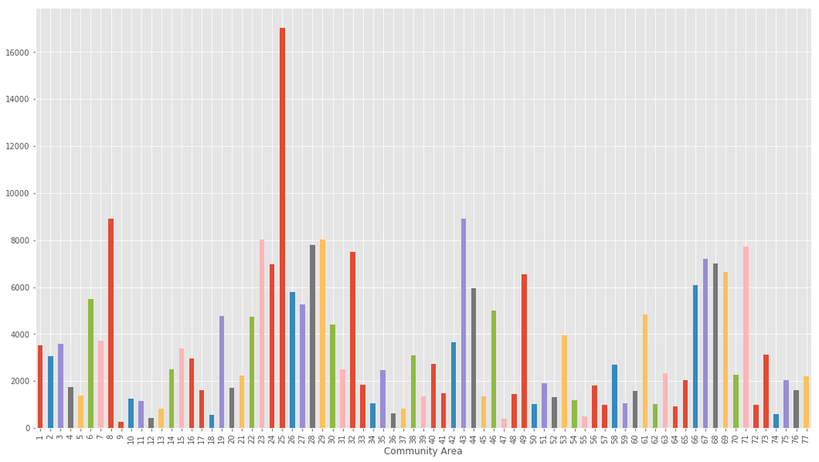

```python
community_crime_count.plot(kind='bar');
```

### 2.

Ordene las Community Areas de acuerdo con el número de crímenes. ¿Qué Community Area (por nombre, idealmente) presenta el mayor número de crímenes? ¿El menor?

```python
community_crime_count.sort_values()
```

```
Community Area
9       254
47      380
12      444
55      506
18      572
74      608
36      622
13      828
37      834
64      927
72      976
57      986
62     1030
50     1037
```

[output cut: 48 more lines]

### 3.

Cree una tabla cuyas filas sean días del año (yyyy-mm-dd) y las columnas las 77 Community Areas. En cada campo de la tabla deberá haber el correspondiente número de crímenes. Seleccione algunas Community Areas que le llamen la atención y haga un gráfico de serie de tiempo.

Pista: El siguiente código puede serle útil.

```python
# Create function to strip time from date field, and use it to create another column
def to_day(timestamp):
    timestamp = pd.to_datetime(timestamp)
    return timestamp.replace(minute=0,hour=0, second=0)

crimes['Day'] = crimes['Date'].apply(to_day)
```

```python
crimes_by_community_day = crimes.groupby(['Community Area', 'Day'])
crimes_by_community_day
crimes_by_community_day_count = crimes_by_community_day['ID'].agg('count')
crimes_by_community_day_count
community_timeseries = crimes_by_community_day_count.unstack('Community Area')
community_timeseries
```

| Community Area Day | 1 | 2 | 3 | 4 | 5 | 6 | 7 | 8 | 9 | 10 | ... | 68 | 69 | 70 | 71 | 72 | 73 | 74 | 75 | 76 | 77 |
| --- | --- | --- | --- | --- | --- | --- | --- | --- | --- | --- | --- | --- | --- | --- | --- | --- | --- | --- | --- | --- | --- |
| 2015-01-01 | 13.0 | 7.0 | 11.0 | 4.0 | 5.0 | 22.0 | 12.0 | 43.0 | 1.0 | 5.0 | ... | 29.0 | 23.0 | 9.0 | 44.0 | 2.0 | 8.0 | 2.0 | 5.0 | 6.0 | 8.0 |
| 2015-01-02 | 5.0 | 9.0 | 8.0 | 3.0 | 2.0 | 10.0 | 9.0 | 27.0 | NaN | 2.0 | ... | 12.0 | 21.0 | 5.0 | 17.0 | 1.0 | 11.0 | 1.0 | 2.0 | 6.0 | 5.0 |
| 2015-01-03 | 7.0 | 11.0 | 9.0 | 7.0 | 4.0 | 6.0 | 11.0 | 27.0 | 1.0 | 3.0 | ... | 23.0 | 12.0 | 8.0 | 18.0 | NaN | 8.0 | 1.0 | 7.0 | 3.0 | 3.0 |
| 2015-01-04 | 12.0 | 7.0 | 9.0 | 10.0 | 3.0 | 15.0 | 5.0 | 16.0 | 1.0 | 4.0 | ... | 13.0 | 15.0 | 9.0 | 12.0 | 1.0 | 5.0 | NaN | 1.0 | 6.0 | 1.0 |
| 2015-01-05 | 6.0 | 7.0 | 5.0 | 4.0 | 5.0 | 15.0 | 7.0 | 11.0 | 1.0 | 3.0 | ... | 16.0 | 12.0 | 8.0 | 17.0 | NaN | 5.0 | 2.0 | 2.0 | 7.0 | 5.0 |
| 2015-01-06 | 7.0 | 8.0 | 6.0 | 5.0 | NaN | 13.0 | 7.0 | 13.0 | NaN | 4.0 | ... | 15.0 | 14.0 | 6.0 | 11.0 | 2.0 | 8.0 | 2.0 | 3.0 | 6.0 | 4.0 |
| 2015-01-07 | 6.0 | 2.0 | 4.0 | 5.0 | 1.0 | 8.0 | 6.0 | 17.0 | 1.0 | 2.0 | ... | 11.0 | 7.0 | 4.0 | 16.0 | 3.0 | 7.0 | NaN | 3.0 | 7.0 | 1.0 |
| 2015-01-08 | 6.0 | 6.0 | 3.0 | 5.0 | NaN | 6.0 | 5.0 | 8.0 | 1.0 | NaN | ... | 9.0 | 9.0 | 6.0 | 10.0 | 2.0 | 4.0 | 1.0 | 5.0 | 3.0 | 3.0 |
| 2015-01-09 | 10.0 | 5.0 | 10.0 | 2.0 | 4.0 | 14.0 | 6.0 | 21.0 | NaN | 3.0 | ... | 18.0 | 14.0 | 10.0 | 20.0 | 1.0 | 9.0 | 2.0 | 8.0 | 5.0 | 2.0 |
| 2015-01-10 | 6.0 | 12.0 | 8.0 | NaN | 1.0 | 10.0 | 5.0 | 24.0 | 2.0 | 2.0 | ... | 9.0 | 13.0 | 6.0 | 28.0 | 3.0 | 3.0 | 1.0 | 5.0 | 5.0 | 2.0 |
| 2015-01-11 | 8.0 | 6.0 | 11.0 | 5.0 | 4.0 | 20.0 | 4.0 | 26.0 | 1.0 | 2.0 | ... | 17.0 | 8.0 | 11.0 | 17.0 | 2.0 | 10.0 | 2.0 | 4.0 | 2.0 | 4.0 |
| 2015-01-12 | 3.0 | 6.0 | 6.0 | 6.0 | 1.0 | 7.0 | 11.0 | 17.0 | NaN | 6.0 | ... | 12.0 | 18.0 | 6.0 | 19.0 | 3.0 | 5.0 | 1.0 | 4.0 | 4.0 | 3.0 |
| 2015-01-13 | 10.0 | 10.0 | 9.0 | 5.0 | 4.0 | 8.0 | 6.0 | 15.0 | NaN | 3.0 | ... | 19.0 | 12.0 | 9.0 | 11.0 | 2.0 | 6.0 | NaN | 4.0 | 6.0 | 6.0 |
| 2015-01-14 | 17.0 | 8.0 | 9.0 | 4.0 | 3.0 | 5.0 | 11.0 | 15.0 | 1.0 | 3.0 | ... | 21.0 | 16.0 | 6.0 | 24.0 | NaN | 5.0 | 1.0 | 1.0 | 2.0 | 6.0 |
| 2015-01-15 | 9.0 | 8.0 | 8.0 | 6.0 | 7.0 | 9.0 | 11.0 | 18.0 | 1.0 | 4.0 | ... | 19.0 | 20.0 | 4.0 | 21.0 | 3.0 | 7.0 | 2.0 | 6.0 | 6.0 | 5.0 |
| 2015-01-16 | 13.0 | 6.0 | 12.0 | 5.0 | 5.0 | 12.0 | 12.0 | 22.0 | 1.0 | 8.0 | ... | 18.0 | 17.0 | 8.0 | 16.0 | 4.0 | 5.0 | NaN | 5.0 | 7.0 | 3.0 |
| 2015-01-17 | 12.0 | 5.0 | 5.0 | 2.0 | 5.0 | 16.0 | 7.0 | 30.0 | 1.0 | 4.0 | ... | 29.0 | 13.0 | 7.0 | 15.0 | 2.0 | 6.0 | 2.0 | 5.0 | 10.0 | 3.0 |
| 2015-01-18 | 12.0 | 6.0 | 12.0 | 7.0 | 5.0 | 14.0 | 8.0 | 18.0 | 1.0 | 2.0 | ... | 20.0 | 22.0 | 3.0 | 20.0 | 1.0 | 11.0 | NaN | 8.0 | 2.0 | 4.0 |
| 2015-01-19 | 3.0 | 12.0 | 7.0 | 3.0 | 5.0 | 10.0 | 11.0 | 25.0 | NaN | 3.0 | ... | 24.0 | 19.0 | 3.0 | 28.0 | NaN | 13.0 | NaN | 6.0 | 8.0 | 4.0 |
| 2015-01-20 | 8.0 | 8.0 | 9.0 | 10.0 | 3.0 | 13.0 | 12.0 | 31.0 | NaN | 4.0 | ... | 19.0 | 15.0 | 5.0 | 23.0 | 1.0 | 10.0 | NaN | 8.0 | 6.0 | 7.0 |
| 2015-01-21 | 18.0 | 8.0 | 8.0 | 10.0 | 9.0 | 12.0 | 9.0 | 29.0 | 2.0 | 2.0 | ... | 11.0 | 12.0 | 7.0 | 29.0 | 5.0 | 2.0 | 2.0 | 6.0 | 3.0 | 9.0 |
| 2015-01-22 | 7.0 | 7.0 | 6.0 | 9.0 | 7.0 | 14.0 | 10.0 | 21.0 | NaN | 6.0 | ... | 19.0 | 13.0 | 11.0 | 22.0 | 1.0 | 5.0 | 1.0 | 6.0 | 4.0 | 6.0 |
| 2015-01-23 | 12.0 | 11.0 | 6.0 | 4.0 | 6.0 | 8.0 | 6.0 | 27.0 | 1.0 | 5.0 | ... | 26.0 | 18.0 | 6.0 | 20.0 | 1.0 | 7.0 | 3.0 | 4.0 | 6.0 | 8.0 |
| 2015-01-24 | 14.0 | 9.0 | 7.0 | 8.0 | 4.0 | 11.0 | 15.0 | 23.0 | NaN | 4.0 | ... | 10.0 | 13.0 | 5.0 | 17.0 | 1.0 | 8.0 | NaN | 3.0 | 5.0 | 10.0 |
| 2015-01-25 | 5.0 | 9.0 | 3.0 | 5.0 | 2.0 | 20.0 | 6.0 | 29.0 | NaN | 2.0 | ... | 15.0 | 13.0 | 7.0 | 15.0 | 3.0 | 4.0 | 1.0 | 6.0 | 3.0 | 5.0 |
| 2015-01-26 | 10.0 | 8.0 | 5.0 | 4.0 | 3.0 | 13.0 | 5.0 | 13.0 | 1.0 | NaN | ... | 18.0 | 16.0 | 10.0 | 29.0 | 1.0 | 8.0 | 1.0 | 9.0 | 2.0 | 8.0 |
| 2015-01-27 | 6.0 | 8.0 | 6.0 | 3.0 | 3.0 | 6.0 | 3.0 | 13.0 | NaN | 3.0 | ... | 20.0 | 16.0 | 9.0 | 20.0 | 2.0 | 11.0 | 2.0 | 6.0 | 3.0 | 5.0 |
| 2015-01-28 | 15.0 | 9.0 | 10.0 | 1.0 | 1.0 | 9.0 | 11.0 | 26.0 | NaN | 1.0 | ... | 13.0 | 16.0 | 3.0 | 18.0 | 2.0 | 7.0 | 1.0 | 6.0 | 5.0 | 6.0 |
| 2015-01-29 | 9.0 | 9.0 | 11.0 | 2.0 | 3.0 | 11.0 | 7.0 | 26.0 | 1.0 | 6.0 | ... | 19.0 | 20.0 | 4.0 | 24.0 | 2.0 | 6.0 | 1.0 | 8.0 | 4.0 | 5.0 |
| 2015-01-30 | 8.0 | 11.0 | 6.0 | 5.0 | 3.0 | 12.0 | 10.0 | 21.0 | NaN | 6.0 | ... | 20.0 | 22.0 | 6.0 | 20.0 | 5.0 | 7.0 | NaN | 6.0 | 2.0 | 4.0 |
| ... | ... | ... | ... | ... | ... | ... | ... | ... | ... | ... | ... | ... | ... | ... | ... | ... | ... | ... | ... | ... | ... |
| 2015-12-02 | 12.0 | 7.0 | 11.0 | 4.0 | 7.0 | 12.0 | 11.0 | 23.0 | 1.0 | 1.0 | ... | 23.0 | 13.0 | 6.0 | 23.0 | 1.0 | 8.0 | 4.0 | 6.0 | 6.0 | 8.0 |
| 2015-12-03 | 6.0 | 11.0 | 9.0 | 2.0 | 4.0 | 12.0 | 7.0 | 32.0 | 1.0 | 1.0 | ... | 16.0 | 19.0 | 7.0 | 17.0 | 2.0 | 7.0 | 3.0 | 3.0 | 2.0 | 4.0 |
| 2015-12-04 | 8.0 | 9.0 | 8.0 | 4.0 | 5.0 | 10.0 | 4.0 | 26.0 | NaN | 3.0 | ... | 18.0 | 15.0 | 3.0 | 21.0 | 1.0 | 7.0 | NaN | 6.0 | 2.0 | 3.0 |
| 2015-12-05 | 9.0 | 7.0 | 5.0 | 5.0 | 5.0 | 8.0 | 13.0 | 33.0 | 1.0 | 2.0 | ... | 13.0 | 20.0 | 5.0 | 26.0 | 3.0 | 9.0 | 3.0 | 5.0 | 2.0 | 4.0 |
| 2015-12-06 | 9.0 | 11.0 | 11.0 | 2.0 | NaN | 20.0 | 8.0 | 24.0 | NaN | 2.0 | ... | 19.0 | 20.0 | 6.0 | 22.0 | 5.0 | 10.0 | 1.0 | 1.0 | 4.0 | 9.0 |
| 2015-12-07 | 7.0 | 10.0 | 8.0 | 1.0 | 6.0 | 10.0 | 8.0 | 19.0 | 1.0 | 3.0 | ... | 20.0 | 21.0 | 3.0 | 30.0 | 3.0 | 8.0 | 2.0 | 6.0 | 4.0 | 6.0 |
| 2015-12-08 | 5.0 | 9.0 | 4.0 | 3.0 | 6.0 | 17.0 | 12.0 | 33.0 | 3.0 | 7.0 | ... | 9.0 | 16.0 | 9.0 | 29.0 | 1.0 | 6.0 | 2.0 | 1.0 | 1.0 | 9.0 |
| 2015-12-09 | 12.0 | 11.0 | 7.0 | 8.0 | 9.0 | 15.0 | 12.0 | 24.0 | NaN | 5.0 | ... | 11.0 | 16.0 | 3.0 | 20.0 | 6.0 | 7.0 | 1.0 | 4.0 | 4.0 | 6.0 |
| 2015-12-10 | 3.0 | 6.0 | 9.0 | 8.0 | 6.0 | 25.0 | 13.0 | 29.0 | 1.0 | 3.0 | ... | 19.0 | 16.0 | 8.0 | 20.0 | 2.0 | 8.0 | 4.0 | 5.0 | 3.0 | 2.0 |
| 2015-12-11 | 11.0 | 7.0 | 11.0 | 6.0 | 5.0 | 19.0 | 10.0 | 29.0 | NaN | 2.0 | ... | 17.0 | 19.0 | 3.0 | 19.0 | 4.0 | 10.0 | 3.0 | 4.0 | 10.0 | 9.0 |
| 2015-12-12 | 10.0 | 5.0 | 7.0 | 8.0 | 4.0 | 25.0 | 15.0 | 38.0 | 1.0 | 2.0 | ... | 17.0 | 16.0 | 9.0 | 19.0 | 1.0 | 7.0 | 2.0 | NaN | 5.0 | 3.0 |
| 2015-12-13 | 7.0 | 12.0 | 10.0 | 3.0 | 4.0 | 21.0 | 9.0 | 38.0 | NaN | 6.0 | ... | 17.0 | 17.0 | 7.0 | 14.0 | NaN | 2.0 | 3.0 | 3.0 | 5.0 | 5.0 |
| 2015-12-14 | 15.0 | 12.0 | 11.0 | 9.0 | 6.0 | 9.0 | 10.0 | 27.0 | 1.0 | 4.0 | ... | 18.0 | 29.0 | 11.0 | 12.0 | 4.0 | 4.0 | 2.0 | 6.0 | 3.0 | 12.0 |
| 2015-12-15 | 10.0 | 6.0 | 11.0 | 5.0 | 3.0 | 10.0 | 21.0 | 24.0 | NaN | 9.0 | ... | 19.0 | 19.0 | 11.0 | 14.0 | NaN | 8.0 | 1.0 | 7.0 | 3.0 | 7.0 |
| 2015-12-16 | 6.0 | 7.0 | 12.0 | 5.0 | 4.0 | 19.0 | 9.0 | 20.0 | 1.0 | 3.0 | ... | 18.0 | 15.0 | 10.0 | 23.0 | 1.0 | 9.0 | 2.0 | 4.0 | 4.0 | 5.0 |
| 2015-12-17 | 8.0 | 8.0 | 8.0 | 7.0 | 5.0 | 18.0 | 19.0 | 28.0 | NaN | 3.0 | ... | 15.0 | 19.0 | 4.0 | 15.0 | NaN | 10.0 | NaN | 6.0 | 7.0 | 7.0 |
| 2015-12-18 | 13.0 | 7.0 | 6.0 | 6.0 | 2.0 | 17.0 | 19.0 | 27.0 | NaN | 3.0 | ... | 15.0 | 16.0 | 7.0 | 19.0 | 3.0 | 9.0 | NaN | 4.0 | 5.0 | 4.0 |
| 2015-12-19 | 7.0 | 11.0 | 6.0 | 3.0 | 1.0 | 10.0 | 12.0 | 41.0 | 2.0 | 3.0 | ... | 10.0 | 12.0 | 5.0 | 21.0 | 1.0 | 7.0 | NaN | 2.0 | 3.0 | 4.0 |
| 2015-12-20 | 12.0 | 8.0 | 13.0 | 7.0 | 3.0 | 18.0 | 10.0 | 21.0 | 1.0 | 2.0 | ... | 15.0 | 23.0 | 5.0 | 15.0 | 3.0 | 7.0 | 2.0 | 2.0 | 5.0 | 1.0 |
| 2015-12-21 | 6.0 | 2.0 | 11.0 | 4.0 | NaN | 6.0 | 11.0 | 32.0 | NaN | 3.0 | ... | 12.0 | 15.0 | 3.0 | 18.0 | 2.0 | 9.0 | 1.0 | 1.0 | 2.0 | 5.0 |
| 2015-12-22 | 13.0 | 11.0 | 15.0 | 5.0 | 4.0 | 13.0 | 9.0 | 26.0 | NaN | NaN | ... | 26.0 | 16.0 | 3.0 | 16.0 | 2.0 | 6.0 | NaN | 5.0 | 2.0 | 8.0 |
| 2015-12-23 | 12.0 | 11.0 | 14.0 | 6.0 | 5.0 | 18.0 | 12.0 | 28.0 | NaN | 3.0 | ... | 18.0 | 23.0 | 8.0 | 19.0 | 1.0 | 9.0 | 4.0 | 8.0 | 2.0 | 7.0 |
| 2015-12-24 | 8.0 | 11.0 | 2.0 | 6.0 | 3.0 | 19.0 | 11.0 | 26.0 | NaN | 7.0 | ... | 16.0 | 22.0 | 4.0 | 19.0 | 3.0 | 3.0 | 2.0 | 5.0 | 3.0 | 5.0 |
| 2015-12-25 | 2.0 | 6.0 | 3.0 | 3.0 | NaN | 5.0 | 5.0 | 10.0 | 1.0 | 5.0 | ... | 13.0 | 15.0 | 3.0 | 18.0 | 1.0 | 5.0 | NaN | 6.0 | 3.0 | 4.0 |
| 2015-12-26 | 6.0 | 11.0 | 12.0 | 1.0 | 1.0 | 17.0 | 5.0 | 26.0 | NaN | 9.0 | ... | 15.0 | 18.0 | 6.0 | 17.0 | 1.0 | 10.0 | NaN | 3.0 | 7.0 | 8.0 |
| 2015-12-27 | 14.0 | 8.0 | 6.0 | 3.0 | 1.0 | 16.0 | 11.0 | 32.0 | NaN | 1.0 | ... | 11.0 | 19.0 | 3.0 | 26.0 | 2.0 | 8.0 | 2.0 | 1.0 | 4.0 | 2.0 |
| 2015-12-28 | 7.0 | 8.0 | 5.0 | 2.0 | 2.0 | 10.0 | 8.0 | 19.0 | NaN | 3.0 | ... | 12.0 | 22.0 | 9.0 | 14.0 | 2.0 | 6.0 | 2.0 | 2.0 | 3.0 | 9.0 |
| 2015-12-29 | 6.0 | 7.0 | 12.0 | 8.0 | 3.0 | 8.0 | 5.0 | 25.0 | NaN | 1.0 | ... | 18.0 | 16.0 | 7.0 | 18.0 | NaN | 8.0 | 3.0 | 2.0 | 2.0 | 4.0 |
| 2015-12-30 | 5.0 | 8.0 | 7.0 | 4.0 | 1.0 | 11.0 | 15.0 | 27.0 | 1.0 | 6.0 | ... | 11.0 | 23.0 | 6.0 | 14.0 | 2.0 | 8.0 | 1.0 | 7.0 | 5.0 | 5.0 |
| 2015-12-31 | NaN | NaN | NaN | NaN | NaN | 1.0 | NaN | NaN | NaN | NaN | ... | NaN | NaN | NaN | NaN | NaN | NaN | NaN | NaN | NaN | NaN |

365 rows × 77 columns

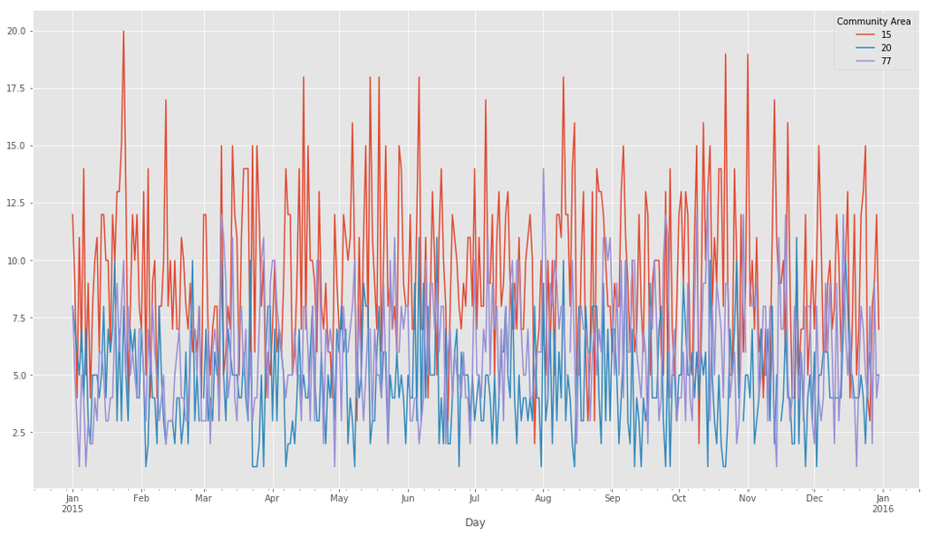

```python
community_timeseries[[15,20,77]].plot();
```

### Parte voluntaria

Descargue la base de datos de información socioeconómica (https://data.cityofchicago.org/Health-Human-Services/Census-Data-Selected-socioeconomic-indicators-in-C/kn9c-c2s2).

### 4.

Cree una tabla que agregue el número de crímenes por Community Area. Una esa tabla con la de datos socioeconómicos y cree un "scatter plot" de número de crímenes vs ingreso per cápita. Explique la relación en palabras.